`geneHapR` is designed for gene haplotype statistics, phenotype association and visualization.

### 1. DATA

#### 1.1 Input data

Dataset required for haplotype statistic, visualization and phenotype association and the import function were listed in Table 1.

The genotype dataset is essential for haplotype identification and could be supplied in VCF, FASTA, P.link, HAPMAP and table format. The annotation were used for variants filtration and prepare schematic diagram.

Detailed information of individuals include phenotype data, group/category information and geo-coordinates. The phenotype data was used for comparison between different haplotypes. The group /category information was used for pie plot with haplotype network (eg. the second column in Table 4). And the geo-coordinates only used for demonstration of geographical distribution and include two columns: longitude and latitude (eg. the third and fourth column in Table 4).

**Table 1: The required format of dataset and import functions for geneHapR**

| Dataset | File format | Import function |
| --- | --- | --- |
| **Genotype** (necessary) | VCF: *.vcf, *.vcf.gz; Sequences: *.fa, *.fasta;* p.link: (*.ped & *.map); hmp: *.hmp; table (eg. Table2): .txt, *.csv | *import_vcf();* import_seqs(); import_plink.pedmap(); import_hmp(); read.table(), read.csv() |
| **Annotation** (optional) | GFF: *.gff,* .gff3, BED4/BED6 (eg. Table3): *.bed | *import_gff()* import_bed() |
| **Accession information** (optional) | table (eg. Table4): *.txt,* .csv | *import_AccINFO()* |

Table 2 is an example of genotypic data in table format: The first five column are fixed as chromosome name (CHROM), position (POS), reference nucleotide (REF), alter nucleotide (ALT) and additional information (INFO). Accession genotype should be in followed columns. “-” will be treated as Indel. “.” and “N” will be treated as missing data. Field in additional information column should be in format “tag=value”, and separated by semicolon “;”. Heterozygote should be looks like “A/G” or “A|G”.

**Table 2: Table format of the genotypic dataset**

| CHR | POS | REF | Alt | INFO | C001 | C002 | C003 | … |
| --- | --- | --- | --- | --- | --- | --- | --- | --- |
| Chr7 | 9154754 | T | C | CDS=G>A;AA=V>G | T | T | T | … |
| Chr7 | 9154664 | G | T | CDS=A>C | G | G | G | … |
| Chr7 | 9154489 | C | G | CDS=C>G | C | C | C | … |
| Chr7 | 9154469 | G | A | CDS=T>C | G | G | G | … |
| ︙ | ︙ | ︙ | ︙ | ︙ | ︙ | ︙ | ︙ |  |

Table 3 is an example of annotation file in BED6 format. As described at [UCSC](http://genome.ucsc.edu/FAQ/FAQformat.html#format1), the BED6 file contains 6 columns: 1) chromosome name, 2) chromosome start, 3) chromosome end, 4) name, 5) score and 6) strand. The BED4 contains the first 4 column of BED6.

**Table 3: An annotation example in BED6 format**

| # CHROM | START | END | GENEID TYPE | . | STRAND |
| --- | --- | --- | --- | --- | --- |
| Chr7 | 9154380 | 9154821 | LOC_Os07g15770.1**·**CDS | . | - |
| Chr7 | 9152403 | 9152730 | LOC_Os07g15770.1**·**CDS | . | - |

Note: the red dot in fourth column indicate a space.

Table 4 is an example of detailed information of individuals, includes group/category, geo-coordinates and phenotype data. First column are names of accessions/individuals, phenotypic information are listed in followed columns.

**Table 4: An example of accession detailed information dataset**

| id | Subpopulation | Longitude | Latitude | Grain length | Grain width | Grain thickness |
| --- | --- | --- | --- | --- | --- | --- |
| C001 | Indica | 121 | 14.6 | 8.5 | 2.9 | 1.96 |
| C002 | Intermediate | 121 | 14.6 | 10.2 | 2.63 | 1.96 |
| C003 | Japonica | 51.3 | 35.45 | 8.75 | 3.32 | 2.12 |
| C004 | Japonica | 116.28 | 39.54 | 7.83 | 3.22 | 2.08 |
| C005 | Japonica | 121 | 14.6 | 10.47 | 3 | 1.95 |
| C006 | Indica | 116.28 | 39.54 | 8.1 | 2.47 | 1.69 |

#### 1.2 Output data

The main results are `hapResult` and `hapSummary` class in R, consist of a matrix which could be divided into three parts as shown in Fig.1, and some additional attributes.

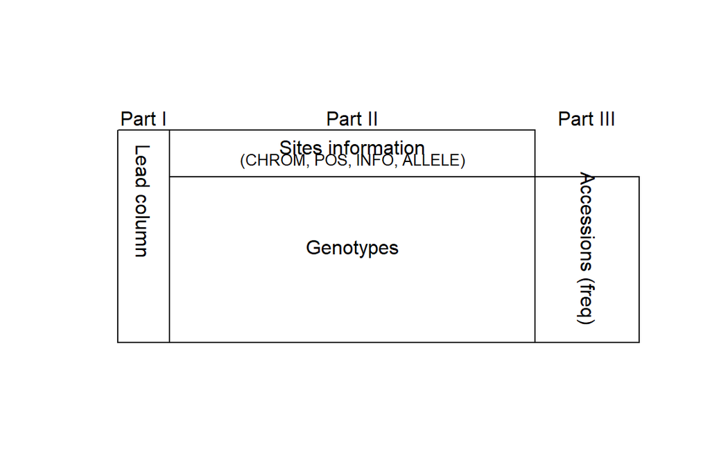

Cartoon representation of hapResult and hapSummary contents

Part I consists of only one column. And the first four lines were fixed as CHROM (chromosome name), POS (position), INFO (additional information) and ALLELE (allele). And followed lines are names of each haplotype. Part II consists of at least one column, contains site information (first four lines) and genotypes (followed lines). The part III of `hapResult` consists of one column named as Accession, while `hapSummary` consists of two columns named as Accession and freq (frequency of each haplotype).

The differences between `hapResult` and `hapSummary` is that each line of `hapResult` indicate an accession/individual, and each line in `hapSummary` indicate a haplotype.

## Installation

`geneHapR` is schemed to submit to CRAN. If accepted, this package could be installed with `install.packages("geneHapR")`. `geneHapR` has not published yet, if you use `geneHapR` in your study, please contact Zhang RenLiang (Maintainer) (email: zhang_renliang@163.com) or Jia GuanQing (jiaguanqing@caas.cn)

```r
install.packages("geneHapR")
```

## Data input

The first step is library the `geneHapR` packages. I will use the test data inside this package as an example for how to perform statistics of a gene/range, visualization and phenotype association analysis.

```r
library(geneHapR)
```

There are two options to conduct a gene haplotype analysis starts from a VCF file or DNA sequences file. Thus a **VCF** file or **DNA sequences** file is necessary. However, the *GFF*, *phenos* and *accession groups* are strongly recommend for visualization and phenotype associations.

The import functions takes file path as input. `import_vcf()` could import VCF file with surfix of “.vcf” and “.vcf.gz”. `import_gff()` import file format default as “GFF” and `import_seqs()` file format default as “fasta”.

### Import VCF

```r
# import vcf file
vcf <- import_vcf("your_vcf_file_path.vcf")

# import gziped vcf file
vcf <- import_vcf("your_vcf_file_path.vcf.gz")
```

### Import p.link (ped/map)

```r
plink <- import_plink.pedmap(mapfile = "p_link.map", pedfile = "p_link.ped",
                             sep_ped = "\t", sep_map = "\t")
plink <- import_plink.pedmap(root = "p_link", sep_ped = "\t", sep_map = "\t")
```

### Import GFF

```r
# import GFFs
gff <- import_gff("your_gff_file_path.gff", format = "GFF")
```

### Import BED

```r
# import GFFs
bed <- import_bed("your_gff_file_path.bed")
```

### Import DNA sequences

```r
# import DNA sequences in fasta format
seqs <- import_seqs("your_DNA_seq_file_path.fa", format = "fasta")
```

## Import phenotype and accession group information

```r
# import phynotype data
pheno <- import_AccINFO("your_pheno_file_path.txt")
pheno
```

```
##    GrainWeight.2021 GrainWeight.2022
## C1            16.76            18.76
## C2             6.66             8.66
## C3             7.80            16.30
## C4            19.73            23.73
## C5            11.95            16.95
## C6            12.43            30.45
```

```r
# import accession group/location information
AccINFO <- import_AccINFO("accession_group_file_path.txt")
```

[output not shown]

Be aware that the phenotype and accession group are effectively tables. There are more than one ways to import a table format file with `R`.

Be **Note** that: a. the accession/individual names located in first column; b. the first row contents phenotype/accession_group names; c. `NA` is allowed, it’s not a wise option to replace `NA` by `0`.

eg.

```r
# import pheno from space ' ' delimed table
pheno <- read.table("your_pheno_file_path.csv", header = TRUE, row.names = 1, comment.char = "#")

# import pheno from ',' delimed table
pheno <- read.csv("your_pheno_file_path.csv", header = TRUE, comment.char = "#")
```

## Data manipulations

There is a little work need to be done before haplotype calculations: (1) VCF filtration and (2) DNA sequences alignment.

### VCF filtration

There are three modes to filter a `vcfR` object after import VCF into ‘R’: a. by position; b. by annotation; c. by both of them.

```r
# filter VCF by position
vcf_f1 <- filter_vcf(vcf, mode = "POS",
                     Chr = "scaffold_1",
                     start = 4300, end = 5890)

# filter VCF by annotation
vcf_f2 <- filter_vcf(vcf, mode = "type",
                     gff = gff,
                     type = "CDS")

# filter VCF by position and annotation
vcf_f3 <- filter_vcf(vcf, mode = "both",
                     Chr = "scaffold_1",
                     start = 4300, end = 5890,
                     gff = gff,
                     type = "CDS")
```

It’s a time consuming work to import and manipulate a very large file with ‘R’ on personal computer. It’ll be more efficiency to extract the target ranges from origin VCF with `filterLargeVCF()` before import. If your VCF file is just a few ‘MB’, this step was not necessary at all.

**Note:** if extract more than one ranges, length of output file names (`VCFout`) must be equal with `Chr` and `POS`.

```r
# new VCF file will be saved to disk
# extract a single gene/range from a large vcf

filterLargeVCF(VCFin = "Ori.vcf.gz",
               VCFout = "filtered.vcf.gz",
               Chr = "scaffold_8",
               POS = c(19802,24501),
               override = TRUE)

# extract multi genes/ranges from large vcf
filterLargeVCF(VCFin = "Ori.vcf.gz",          # surfix should be .vcf.gz or .vcf
               VCFout = c("filtered1.vcf.gz", # surfix should be .vcf.gz or .vcf
                          "filtered2.vcf.gz",
                          "filtered3.vcf.gz"),
               Chr = c("scaffold_8",
                       "scaffold_8",
                       "scaffold_7"),
               POS = list(c(19802,24501),
                          c(27341,28949),
                          c(38469,40344)),
               override = TRUE)               # if TRUE, existed file will be override without warning
```

### p.link (ped/map) filtration

```r
p.link <- filter_plink.pedmap(p.link, mode = "POS",
                              Chr = "Chr08", start = 25947258, end = 25948258)
```

### DNA sequences manipulation

The origin DNA sequences must be aligned and trimmed due to haplotype calculation need all sequences have same length. Those operations could be done with `geneHapR`. I still suggest users align and trim DNA sequences with **Mega** software and then save the result as *FASTA* format before import them into ‘R’.

```r
# sequences alignment
seqs <- allignSeqs(seqs, quiet = TRUE)

# sequences trim
seqs <- trimSeqs(seqs, minFlankFraction = 0.1)
seqs
```

### hapResult/hapSummary filtration

```r
hap <- filter_hap(hapSummary,
                  rm.mode = c("position", "accession", "haplotype", "freq"),
                  position.rm = c(4879, 4950),
                  accession.rm = c("C1", "C9"),
                  haplotype.rm = c("H009", "H008"),
                  freq.min = 5)
```

## Haplotype calculation

As mentioned before, haplotype could be calculated from VCF or sequences with `vcf2hap()` or `seqs2hap()`. The genotype of most sites should be known and homozygous, still, a few site are unknown or heterozygous due to chromosome variant or error cased by sequencing or SNP calling or gaps or other reasons. It’s a hard decision whether to drop accessions/individuals contains heterozygous or unknown sites for every haplotype analysis. Hence, I leave the choice to users.

Calculate haplotype result from VCF.

```r
hapResult <- vcf2hap(vcf,
                     hapPrefix = "H",
                     hetero_remove = TRUE,
                     na_drop = TRUE)
hapResult
```

```
## Accessions:
##  All:      37
##  Removed: 4  C12, C16, C29, C33
##  Remain:  33
##
## hap frequences:
## H001 H002 H003 H004 H005 H006 H007 H008 H009
##   10    8    4    4    2    2    1    1    1
##
## Options:
##   hapPrefix: H
##       CHROM: scaffold_1
##         POS: 4300-6856
##  hetero_remove: YES
##   NA_remove: YES
##
## # A tibble: 37 × 11
##   Hap   `4300` `6856` `5209` `5213` `4910` `4879` `4345` `4950` `5037` Accession
##   <chr> <chr>  <chr>  <chr>  <chr>  <chr>  <chr>  <chr>  <chr>  <chr>  <chr>
## 1 CHR   scaff… scaff… scaff… scaff… scaff… scaff… scaff… scaff… scaff… ""
## 2 POS   4300   6856   5209   5213   4910   4879   4345   4950   5037   ""
## 3 INFO  <NA>   <NA>   <NA>   <NA>   <NA>   <NA>   <NA>   <NA>   <NA>   ""
## 4 ALLE… G/C    A/G    A/AC   C/G    GCCTA… T/A,G  T/A,GG T/AA,… A/AA,… ""
## 5 H001  G      A      A      C      GCCTA  T      T      T      A      "C8"
## 6 H001  G      A      A      C      GCCTA  T      T      T      A      "C9"
## 7 H001  G      A      A      C      GCCTA  T      T      T      A      "C11"
```

Calculate haplotype result from aligned DNA sequences.

```r
hapResult <- seqs2hap(seqs,
                      Ref = names(seqs)[1],
                      hapPrefix = "H",
                      hetero_remove = TRUE,
                      na_drop = TRUE,
                      maxGapsPerSeq = 0.25)
```

## Adjustment of `hapResult`

Before visualization, there were a few details need to be adjusted. eg. add annotations and adjust position of “ATG”

### Add annotations to `hapResult`

While `hapResult` was calculated from `vcfR` object, the **INFO** was taken from `@fix` field. The *VCF INFO* may missing some annotations. or contents format was inappropriate to display. Further more, **INFO** contents nothing if `hapResult` was generated from sequences. Here, we can introduce/replace the origin **INFO** by `addINFO()`.

**Note** that: length of `values` must be equal with number of sites.

Let’s see how mant sites contains in the `hapResult`.

```r
# Chech number of sites conclude in hapResult
sites(hapResult)
```

```
## [1] 9
```

Now we replace the old INFO field with new tag named as “PrChange”.

```r
# add annotations to INFO field
hapResult <- addINFO(hapResult,
                     tag = "PrChange",
                     values = rep(c("C->D", "V->R", "G->N"),3),
                     replace = TRUE)
```

Here, we add a tag named as “CDSChange” followed the old INFO.

```r
# To replace the origin INFO by set 'replace' as TRUE
hapResult <- addINFO(hapResult,
                     tag = "CDSChange",
                     values = rep(c("C->A", "T->C", "G->T"),3),
                     replace = FALSE)
```

### Adjust position of “ATG”

This function was only used to adjust the position of “ATG” to 0 and hence convert the gene on negative strand to positive strand.

Be note that: **GFF** and **hapResult** need to adjust position of *ATG* with the same parameters.

```r
# set ATG position as zero in gff
newgff <- gffSetATGas0(gff = gff, hap = hapResult,
                       geneID = "test1G0387",
                       Chr = "scaffold_1",
                       POS = c(4300, 7910))

# set position of ATG as zero in hapResult/hapSummary
newhap <- hapSetATGas0(gff = gff, hap = hapResult,
                       geneID = "test1G0387",
                       Chr = "scaffold_1",
                       POS = c(4300, 7910))
```

## `hapResult` summary and visualization

Once we have the `hapResult` object, can we summarize and visualize our `hapResult` by interact with annotations and phenotypes.

### Summary hapResult

Now, we have the `hapResult` object with INFOs we want display in next step. The `hap_summary()` function convert the object of `hapResult` class, which is a long table format, into a short table belong to `hapSummary` class. In `hapResult` each row represent a accession, while each row represents a hap in `hapSummary`.

```r
hapSummary <- hap_summary(hapResult)
hapSummary
```

```
##
## Accssions: 33
## Sites: 9
##   Indels: 5
##   SNPs:   4
##
## Haplotypes: 9
##   H001   10  C8, C9, C11, C14, C18, C25, ...
##   H002   8   C5, C15, C17, C19, C22, C32, ...
##   H003   4   C6, C20, C23, C37
##   H004   4   C7, C13, C24, C30
##   H005   2   C4, C21
##   H006   2   C10, C27
##   H007   1   C1
##   H008   1   C2
##   H009   1   C3
##
## Options:
##  hapPrefix:  H
##  CHROM:  scaffold_1
##  POS:    4300-6856
##  hetero_remove:  YES
##  NA_remove:  YES
##
## # A tibble: 13 × 12
##   Hap   `4300` `6856` `5209` `5213` `4910` `4879` `4345` `4950` `5037` Accession
##   <chr> <chr>  <chr>  <chr>  <chr>  <chr>  <chr>  <chr>  <chr>  <chr>  <chr>
## 1 CHR   scaff… scaff… scaff… scaff… scaff… scaff… scaff… scaff… scaff… "Haploty…
## 2 POS   4300   6856   5209   5213   4910   4879   4345   4950   5037   "Individ…
## 3 INFO  PrCha… PrCha… PrCha… PrCha… PrCha… PrCha… PrCha… PrCha… PrCha… "Variant…
## 4 ALLE… G/C    A/G    A/AC   C/G    GCCTA… T/A,G  T/A,GG T/AA,… A/AA,… ""
## 5 H001  G      A      A      C      GCCTA  T      T      T      A      "C8;C9;C…
## 6 H002  C      A      A      G      A      T      T      T      A      "C5;C15;…
## 7 H003  G      A      AC     G      A      A      A      AA     AA     "C6;C20;…
```

### Visualize haplotye as table

Let’s see how to visualization of our haplotype results.

At first let’s display the `hapSummary` as a table. In this table like figure we can see all the variants and their positions, haplotypes and their frequencies.

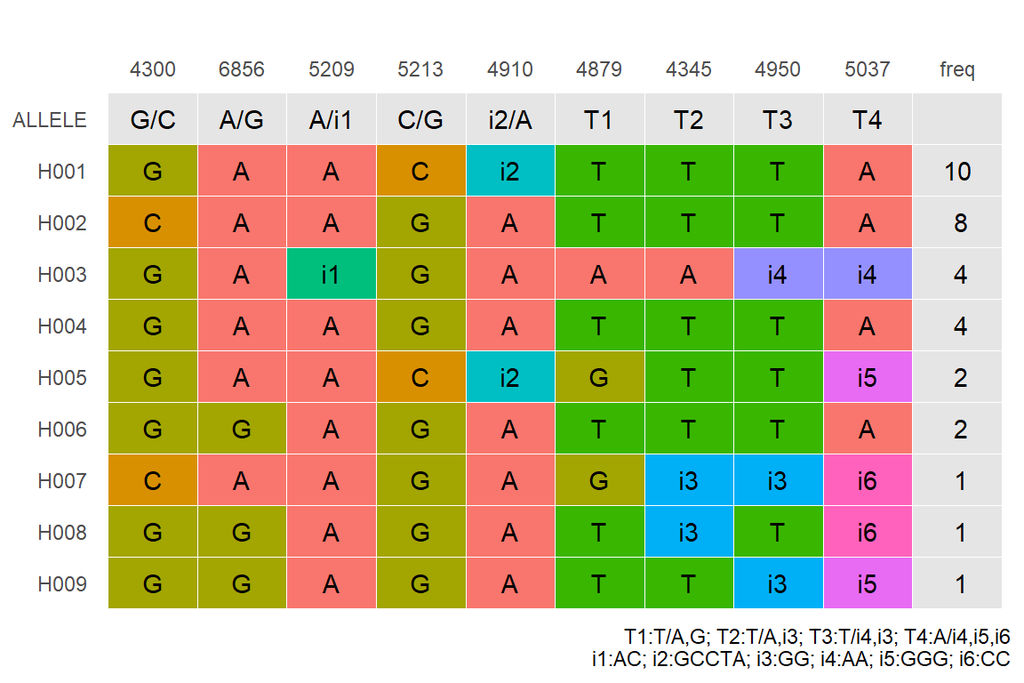

```r
plotHapTable(hapSummary)
```

Also we can add an annotation, “CDSChange”, to the table by assign the `INFO_tag`. It’s your responsibility to verify whether the INFO_tag was existed in the INFO field.

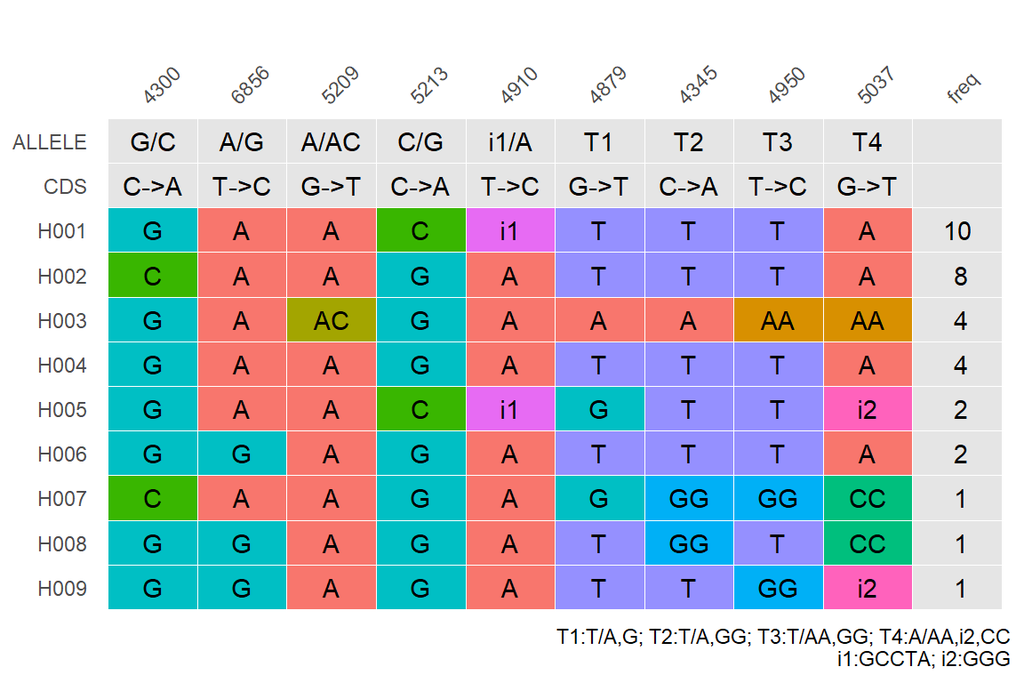

```r
# add one annotation
plotHapTable(hapSummary,
             hapPrefix = "H",
             INFO_tag = "CDSChange",
             tag_name = "CDS",
             displayIndelSize = 1,
             angle = 45,
             replaceMultiAllele = TRUE,
             ALLELE.color = "grey90")
```

Now let’s add another `INFO_tag` named as “PrChange”.

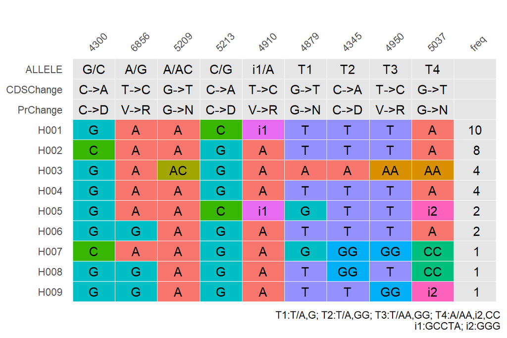

```r
# add multi annotation
plotHapTable(hapSummary,
             hapPrefix = "H",
             INFO_tag = c("CDSChange", "PrChange"),
             displayIndelSize = 1,
             angle = 45,
             replaceMultiAllele = TRUE,
             ALLELE.color = "grey90")
```

Parameter `tag_name` was used to replace the character if `INFO_tag` was too long.

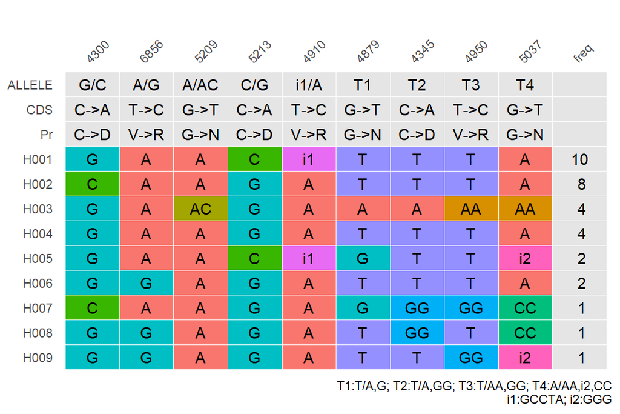

```r
# add multi annotation
plotHapTable(hapSummary,
             hapPrefix = "H",
             INFO_tag = c("CDSChange", "PrChange"),
             tag_name = c("CDS", "Pr"),
             displayIndelSize = 1,
             angle = 45,
             replaceMultiAllele = TRUE,
             ALLELE.color = "grey90")
```